# Forced Rayleigh Oscillator

## Superharmonic case

Support material for the book **Perturbation Methods using Backward Error** by Robert M. Corless and Nicolas Fillion, in preparation.

Copyright (c) 2024 Robert M. Corless

Permission is hereby granted, free of charge, to any person obtaining a copy of this software and associated documentation files (the “Software”), to deal in the Software without restriction, including without limitation the rights to use, copy, modify, merge, publish, distribute, sublicense, and/or sell copies of the Software, and to permit persons to whom the Software is furnished to do so, subject to the following conditions:

The above copyright notice and this permission notice shall be included in all copies or substantial portions of the Software.

THE SOFTWARE IS PROVIDED “AS IS”, WITHOUT WARRANTY OF ANY KIND, EXPRESS OR IMPLIED, INCLUDING BUT NOT LIMITED TO THE WARRANTIES OF MERCHANTABILITY, FITNESS FOR A PARTICULAR PURPOSE AND NONINFRINGEMENT. IN NO EVENT SHALL THE AUTHORS OR COPYRIGHT HOLDERS BE LIABLE FOR ANY CLAIM, DAMAGES OR OTHER LIABILITY, WHETHER IN AN ACTION OF CONTRACT, TORT OR OTHERWISE, ARISING FROM, OUT OF OR IN CONNECTION WITH THE SOFTWARE OR THE USE OR OTHER DEALINGS IN THE SOFTWARE.

$\newcommand{\e}{\varepsilon}$

This notebook explores the **strongly** forced Rayleigh oscillator \begin{equation} \ddot{y} - \e \dot{y}\left( 1 - \frac{4}{3}\dot{y}^2 \right) + y = 2 F\cos(\Omega t + \Phi) \end{equation} for $\Omega \approx 1/3$.

We then compute perturbation expansion up to and including the $O(\e^N)$ terms, so it has a residual $O(\e^{N+1})$.

Define $N$ in the next cell.

```python
N := 2;
```

```
kilobytes used=1680, alloc=5424, time=0.33
```

$$2$$

Put $\tau = \Omega t$, where $\Omega = 1/3 + \sigma \e/2$.

```python
macro( e=varepsilon ):
Omega := 1/3 + sigma*e/2: # Traditional to include /2
Phi := 0: # Plays no role
WeaklyNonlineart := diff(y(t), t, t)
  - e*diff(y(t), t)*(1 - 4/3*diff(y(t), t)^2) + y(t)
  - F*exp(I*(tau+Phi)) - F*exp(-I*(tau+Phi)) :
tmp := PDETools:-dchange( t=tau/Omega, WeaklyNonlineart, [tau]):
WeaklyNonlinear := expand( 9*eval(tmp, y(tau,sigma,e)=y(tau) ));
```

$$\frac{d^{2}}{d \tau^{2}}y \left(\tau \right)+3 \left(\frac{d^{2}}{d \tau^{2}}y \left(\tau \right)\right) \sigma \varepsilon +\frac{9 \left(\frac{d^{2}}{d \tau^{2}}y \left(\tau \right)\right) \sigma^{2} \varepsilon^{2}}{4}-3 \varepsilon \left(\frac{d}{d \tau}y \left(\tau \right)\right)+\frac{4 \varepsilon \left(\frac{d}{d \tau}y \left(\tau \right)\right)^{3}}{9}+2 \varepsilon^{2} \left(\frac{d}{d \tau}y \left(\tau \right)\right)^{3} \sigma +3 \varepsilon^{3} \left(\frac{d}{d \tau}y \left(\tau \right)\right)^{3} \sigma^{2}-\frac{9 \varepsilon^{2} \left(\frac{d}{d \tau}y \left(\tau \right)\right) \sigma}{2}+\frac{3 \varepsilon^{4} \left(\frac{d}{d \tau}y \left(\tau \right)\right)^{3} \sigma^{3}}{2}+9 y \left(\tau \right)-9 F \,{\mathrm e}^{\mathrm{I} \tau}-\frac{9 F}{{\mathrm e}^{\mathrm{I} \tau}}$$

```python
sol := dsolve( eval( WeaklyNonlinear, e=0), y(tau) );
```

```
kilobytes used=5697, alloc=13886, time=0.78
```

$$y \left(\tau \right) = \sin \left(3 \tau \right) c_{2} +\cos \left(3 \tau \right) c_{1} +\frac{9 F \cos \left(\tau \right)}{4}$$

That solution has sines and cosines. We will work over the complex exponentials first. Use the variable zs to keep the solution in.

```python
ys := Array(0 .. N): # Placeholder for secular solution terms
rs := Array(0 .. N): # Placeholder for residuals
ys[0] :=  A*exp(I*phi)*exp(3*I*tau) + A*exp(-I*phi)*exp(-3*I*tau)
          + combine( expand( convert( 9*F*cos(tau)/4, exp ) ), exp):
zs := ys[0];
```

$$A \,{\mathrm e}^{\mathrm{I} \phi} {\mathrm e}^{3 \,\mathrm{I} \tau}+A \,{\mathrm e}^{\mathrm{-I} \phi} {\mathrm e}^{-3 \,\mathrm{I} \tau}+\frac{9 F \,{\mathrm e}^{\mathrm{I} \tau}}{8}+\frac{9 F \,{\mathrm e}^{\mathrm{-I} \tau}}{8}$$

We will work with sines and cosines in the end, but to get the secular equation we will convert to exponentials.

```python
# SHOlveTerm --- solve a simple harmonic oscillator, harmonically forced
#
#
# dsolve can be inefficient at solving y'' + omega^2*y = sum of simple terms
# (probably getting bogged down in type checking or simplification
#  or its own heuristics, or perhaps it's just its generality).
# This routine attempts to do this simpler task more efficiently,
# by giving up on generality.
#
# Input: expr  : right-hand side: polynomial in sine/cos/exp only
#                with coefficients polynomials in var
#        var   : variable (usually t)
#        omega : natural frequency
#
# Processing: map over a sum of terms
#             match the terms to poly(var)*exp( I*(freq*var + phase) )
#                            or  poly(var)*sin( freq*var + phase )
#                            or  poly(var)*cos( freq*var + phase )
#
#          solve the problem y'' + omega^2*y = sum poly(var)* fn( freq*var+phase )
#
# Output: a particular solution to y'' + omega^2 = ...
#         where the rhs is a sum of polynomials in var times sin/cos/exp.
#
# Comments: dsolve would solve this, but for large expressions might take
# a seemingly unreasonable length of time to do so, and may return
# unevaluated integrals (because it thinks the answers are too complicated).
# However, this simple routine will not succeed for unexpected inputs.
# Take your pick.

SHOlveTerm := proc( expr, var, omega )
	local A, c, fn, freq, la, m, phase, sol, term, zerp;
	description "Solve y''+ omega^2*y=expr";
    if has( expr, sin ) or has( expr, cos ) then
      # convert,exp will make cos(A) --> (exp(I*A)+exp(-I*A))/2, etc
      # expand will expand (A*exp(B) + C*exp(D))*(E*exp(F)+G*exp(H))
      # to A*E*exp(B)*exp(F) + A*G*exp(B)*exp(H) + ...
      # combine,exp will make exp(B)*exp(F)-->exp(B+F)
      term := combine( expand( convert(expr,exp ) ), exp );
    else
      term := expr;
    end if;
	if type( term, `+` ) then
      # Apply this procedure to each term in a sum
	  return map( procname, term, var, omega );
	else
      # Look for A*exp(I*(freq*var+phase))
      term := combine( term, exp );
      A := eval(term, exp=1);
      fn := normal( term/A );
      # Each term *should* be A*exp(B).  Should be.
      if normal( expr-A*fn ) <> 0 then
        error "Unexpected term type", term;
      end if;
      # Identify frequency and phase
      if match( fn=exp(I*(freq*var+phase)), var, 'la' ) then
        if eval(freq,la)^2 = omega^2 then
          # resonant case
          m := degree(A, var) + 1; # A must be polynomial
        else
          m := degree(A, var);
        end if;
        P := add( c[k]*var^k, k=0..m );
        # y = P(var)*exp(I*(freq*var+phase))
        # for P(var) a polynomial to be found.
        zerp := eval( omega^2*P + diff(P,var,var) + 2*I*freq*diff(P,var) - freq^2*P - A, la);
        sol := solve( {seq( coeff(zerp,var,k), k=0..m)}, {seq(c[k],k=0..m)} );
        # triangular system, guaranteed to have a solution
        # Throw away the redundant terms c[0]*exp(I*(freq*var+phase))
        return eval( eval( eval(P,sol), c[0]=0)*exp(I*(freq*var+phase)), la );
      else
        error "Unexpected term type, after match", term, A, fn;
      end if;
    end if;
end proc:
```

```python
loop_start := time():
times := Array(1 .. N):
for k to N do
    residuals[k - 1] := combine(expand(
                          coeff(eval(WeaklyNonlinear, y(tau) = zs), e, k)),
                          exp);
    newans := SHOlveTerm( residuals[k-1], tau, 3 );
    ys[k] := -newans;
    zs := zs + ys[k]*e^k;
    times[k] := time();
end do:
```

```
kilobytes used=13335, alloc=18494, time=1.42
```

```python
zs;
```

$$A \,{\mathrm e}^{\mathrm{I} \phi} {\mathrm e}^{3 \,\mathrm{I} \tau}+A \,{\mathrm e}^{\mathrm{-I} \phi} {\mathrm e}^{-3 \,\mathrm{I} \tau}+\frac{9 F \,{\mathrm e}^{\mathrm{I} \tau}}{8}+\frac{9 F \,{\mathrm e}^{\mathrm{-I} \tau}}{8}+\left(-\frac{27 \,\mathrm{I} F \,{\mathrm e}^{\mathrm{-I} \tau}}{64}+\frac{27 \,\mathrm{I} F \,{\mathrm e}^{\mathrm{I} \tau}}{64}-\frac{243 \,\mathrm{I} F^{3} {\mathrm e}^{\mathrm{I} \tau}}{1024}+\frac{\mathrm{I} A^{3} {\mathrm e}^{\mathrm{I} \left(-3 \phi -9 \tau \right)}}{6}-\frac{\mathrm{I} A^{3} {\mathrm e}^{\mathrm{I} \left(3 \phi +9 \tau \right)}}{6}+\frac{243 \,\mathrm{I} F^{3} {\mathrm e}^{\mathrm{-I} \tau}}{1024}-\frac{27 \,\mathrm{I} F \,A^{2} {\mathrm e}^{\mathrm{I} \left(2 \phi +7 \tau \right)}}{80}-\frac{81 \,\mathrm{I} F^{2} A \,{\mathrm e}^{\mathrm{I} \left(-\phi -\tau \right)}}{128}+\frac{27 \,\mathrm{I} F \,A^{2} {\mathrm e}^{\mathrm{I} \left(2 \phi +5 \tau \right)}}{32}-\frac{81 \,\mathrm{I} F^{2} A \,{\mathrm e}^{\mathrm{I} \left(\phi +5 \tau \right)}}{256}-\frac{27 \,\mathrm{I} A^{2} F \,{\mathrm e}^{\mathrm{I} \tau}}{8}-\frac{27 \,\mathrm{I} F \,A^{2} {\mathrm e}^{\mathrm{I} \left(-2 \phi -5 \tau \right)}}{32}+\frac{81 \,\mathrm{I} F^{2} A \,{\mathrm e}^{\mathrm{I} \left(-\phi -5 \tau \right)}}{256}+\frac{27 \,\mathrm{I} A^{2} F \,{\mathrm e}^{\mathrm{-I} \tau}}{8}+\frac{81 \,\mathrm{I} F^{2} A \,{\mathrm e}^{\mathrm{I} \left(\phi +\tau \right)}}{128}+\frac{27 \,\mathrm{I} F \,A^{2} {\mathrm e}^{\mathrm{I} \left(-2 \phi -7 \tau \right)}}{80}+\frac{9 \,\mathrm{I} \sigma A \tau \,{\mathrm e}^{\mathrm{I} \left(-\phi -3 \tau \right)}}{2}-\frac{9 \,\mathrm{I} \sigma A \tau \,{\mathrm e}^{\mathrm{I} \left(\phi +3 \tau \right)}}{2}+\frac{3 A \tau \,{\mathrm e}^{\mathrm{I} \left(-\phi -3 \tau \right)}}{2}+\frac{3 A \tau \,{\mathrm e}^{\mathrm{I} \left(\phi +3 \tau \right)}}{2}-6 A^{3} \tau \,{\mathrm e}^{\mathrm{I} \left(\phi +3 \tau \right)}-6 A^{3} \tau \,{\mathrm e}^{\mathrm{I} \left(-\phi -3 \tau \right)}+\frac{27 F^{3} \tau \,{\mathrm e}^{-3 \,\mathrm{I} \tau}}{256}+\frac{27 F^{3} \tau \,{\mathrm e}^{3 \,\mathrm{I} \tau}}{256}-\frac{27 A \,F^{2} \tau \,{\mathrm e}^{\mathrm{I} \left(\phi +3 \tau \right)}}{16}-\frac{27 A \,F^{2} \tau \,{\mathrm e}^{\mathrm{I} \left(-\phi -3 \tau \right)}}{16}+\frac{27 \sigma F \,{\mathrm e}^{\mathrm{-I} \tau}}{64}+\frac{27 \sigma F \,{\mathrm e}^{\mathrm{I} \tau}}{64}\right) \varepsilon +\left(-\left(-\frac{27 \,\mathrm{I} A^{2} F^{3} \tau}{512}-\frac{27 A^{2} F^{3}}{2048}\right) {\mathrm e}^{\mathrm{I} \left(-2 \phi -9 \tau \right)}-\left(-\frac{729 \,\mathrm{I} A^{2} F^{3} \tau}{256}-\frac{3645 A^{2} F^{3}}{2048}\right) {\mathrm e}^{\mathrm{I} \left(-2 \phi -5 \tau \right)}-\left(-\frac{81 \,\mathrm{I} A^{4} F \tau}{8}-\frac{405 A^{4} F}{64}\right) {\mathrm e}^{\mathrm{I} \left(-2 \phi -5 \tau \right)}-\left(\frac{729 F^{5} \tau^{2}}{8192}-\frac{243 \,\mathrm{I} F^{5} \tau}{8192}\right) {\mathrm e}^{-3 \,\mathrm{I} \tau}-\left(\frac{2187 \,\mathrm{I} F^{5} \tau}{6553…

```python
resonant := 0; # Collect all terms of the form P(t)*exp(I*t).
ze := expand( combine( expand(zs), exp ) ):
trms := [op(ze)];
for k to numelems( trms ) do
  trm := combine( trms[k], exp );
  conpart := eval(trm,exp=1); # trm = A*exp(B) we hope
  expart := normal( trm/conpart );
  if match( combine(expart,exp)=exp(3*I*tau + phase), tau, 'la') then
    resonant := resonant + conpart*eval(exp(phase),la);
  end if;
end do:
```

[output not shown]

```python
ze;
```

$$-\frac{1323 \,\mathrm{I} \varepsilon^{2} A^{2} F^{3} \tau}{512 \left({\mathrm e}^{\tau \mathrm{I}}\right)^{3}}+\frac{1323 \,\mathrm{I} \varepsilon^{2} A^{2} F^{3} \tau \left({\mathrm e}^{\tau \mathrm{I}}\right)^{3}}{512}-\frac{243 \,\mathrm{I} \varepsilon^{2} \left({\mathrm e}^{\tau \mathrm{I}}\right)^{3} \sigma \,F^{3} \tau^{2}}{1024}+\frac{729 \,\mathrm{I} \varepsilon^{2} {\mathrm e}^{\tau \mathrm{I}} A^{2} F^{3} \tau}{64}+\frac{243 \,\mathrm{I} \varepsilon^{2} \sigma \,F^{3} \tau^{2}}{1024 \left({\mathrm e}^{\tau \mathrm{I}}\right)^{3}}+\frac{81 \,\mathrm{I} \varepsilon^{2} {\mathrm e}^{\tau \mathrm{I}} A^{4} F \tau}{2}-\frac{81 \,\mathrm{I} \varepsilon^{2} {\mathrm e}^{\tau \mathrm{I}} A^{2} F \tau}{8}-\frac{729 \,\mathrm{I} \varepsilon^{2} A^{2} F^{3} \tau}{64 \,{\mathrm e}^{\tau \mathrm{I}}}-\frac{81 \,\mathrm{I} \varepsilon^{2} A^{4} F \tau}{2 \,{\mathrm e}^{\tau \mathrm{I}}}+\frac{81 \,\mathrm{I} \varepsilon^{2} A^{2} F \tau}{8 \,{\mathrm e}^{\tau \mathrm{I}}}-\frac{3 \,\mathrm{I} \varepsilon^{2} A^{5} \tau}{{\mathrm e}^{\phi \mathrm{I}} \left({\mathrm e}^{\tau \mathrm{I}}\right)^{3}}+3 \,\mathrm{I} \varepsilon^{2} A^{5} \tau \,{\mathrm e}^{\phi \mathrm{I}} \left({\mathrm e}^{\tau \mathrm{I}}\right)^{3}-\frac{81 \varepsilon^{2} \left({\mathrm e}^{\phi \mathrm{I}}\right)^{2} \left({\mathrm e}^{\tau \mathrm{I}}\right)^{3} A^{2} F^{3} \tau^{2}}{256}+\frac{243 \,\mathrm{I} \varepsilon^{2} \sigma \,A^{2} F}{32 \,{\mathrm e}^{\tau \mathrm{I}}}+3 \,\mathrm{I} \varepsilon^{2} \left({\mathrm e}^{\phi \mathrm{I}}\right)^{3} \left({\mathrm e}^{\tau \mathrm{I}}\right)^{9} A^{5} \tau -\frac{3 \,\mathrm{I} \varepsilon^{2} \left({\mathrm e}^{\phi \mathrm{I}}\right)^{3} \left({\mathrm e}^{\tau \mathrm{I}}\right)^{9} A^{3} \tau}{4}-\frac{3 \,\mathrm{I} \varepsilon^{2} A^{5} \tau}{\left({\mathrm e}^{\phi \mathrm{I}}\right)^{3} \left({\mathrm e}^{\tau \mathrm{I}}\right)^{9}}+\frac{3 \,\mathrm{I} \varepsilon^{2} A^{3} \tau}{4 \left({\mathrm e}^{\phi \mathrm{I}}\right)^{3} \left({\mathrm e}^{\tau \mathrm{I}}\right)^{9}}+\frac{729 \varepsilon^{2} {\mathrm e}^{\phi \mathrm{I}} \left({\mathrm e}^{\tau \mathrm{I}}\right)^{3} F^{4} A \,\tau^{2}}{512}-\frac{81 \varepsilon^{2} \sigma^{2} A \,\tau^{2}}{8 \,{\mathrm e}^{\phi \mathrm{I}} \left({\mathrm e}^{\tau \mathrm{I}}\right)^{3}}-\frac{81 \varepsilon^{2} {\mathrm e}^{\phi \mathrm{I}} \left({\mathrm e}^{\tau \mathrm{I}}\right)^{3} \sigma^{2} A \,\tau^{2}}{8}+\frac{81 \varepsilon^{2} F^{2} A^{3} \tau^{2}}{4 \,{\mathrm e}^{\phi \mathrm{I}} \left({\mathrm e}^{\tau \mathrm{I}}\right)^{3}}+\frac{81 \varepsilon^{2} {\mathrm e}^{\phi \mathrm{I}} \left({\mathrm e}^{\tau \mathrm{I}}\right)^{3} F^{2} A^{3} \tau^{2}}{4}-\frac{81 \varepsilon^{2} F^{2} A \,\tau^{2}}{32 \,{\mathrm e}^{\phi \mathrm{I}} \left({\mathrm e}^{\tau \mathrm{I}}\right)^{3}}-\frac{81 \varepsilon^{2} {\mathrm e}^{\phi \mathrm{I}} \left({\mathrm e}^{\tau \mathrm{I}}\right)^{3} F^{2} A \,\tau^{2}}{32}-\frac{9 \varepsilon^{2} \left({\mathrm e}^{\phi \mathrm…

```python
yA := resonant/(A*exp(I*phi));
```

$$\frac{\frac{81 \varepsilon^{2} F^{2} A^{3} \tau^{2} {\mathrm e}^{\phi \mathrm{I}}}{4}-\frac{81 \varepsilon^{2} \sigma^{2} A \,\tau^{2} {\mathrm e}^{\phi \mathrm{I}}}{8}+\frac{729 \varepsilon^{2} F^{4} A \,\tau^{2} {\mathrm e}^{\phi \mathrm{I}}}{512}+\frac{729 \varepsilon^{2} \sigma \,F^{3} \tau}{2048}+A \,{\mathrm e}^{\phi \mathrm{I}}+\frac{3 \varepsilon A \tau \,{\mathrm e}^{\phi \mathrm{I}}}{2}-6 \varepsilon \,A^{3} \tau \,{\mathrm e}^{\phi \mathrm{I}}-\frac{81 \varepsilon^{2} F^{2} A \,\tau^{2} {\mathrm e}^{\phi \mathrm{I}}}{32}+9 \varepsilon^{2} A^{3} \sigma \tau \,{\mathrm e}^{\phi \mathrm{I}}-\frac{3 \,\mathrm{I} \varepsilon^{2} A \tau \,{\mathrm e}^{\phi \mathrm{I}}}{8}+\frac{27 \,\mathrm{I} \varepsilon^{2} \sigma^{2} A \tau \,{\mathrm e}^{\phi \mathrm{I}}}{4}-\frac{9 \,\mathrm{I} \varepsilon \sigma A \tau \,{\mathrm e}^{\phi \mathrm{I}}}{2}-\frac{81 \,\mathrm{I} \varepsilon^{2} A^{2} F^{3} \tau \,{\mathrm e}^{2 \phi \mathrm{I}}}{1024}+27 \,\mathrm{I} \varepsilon^{2} A^{3} \sigma \,\tau^{2} {\mathrm e}^{\phi \mathrm{I}}-\frac{27 \,\mathrm{I} \varepsilon^{2} \sigma A \,\tau^{2} {\mathrm e}^{\phi \mathrm{I}}}{4}-\frac{9 \varepsilon^{2} \sigma A \tau \,{\mathrm e}^{\phi \mathrm{I}}}{4}-\frac{81 \varepsilon^{2} A^{2} F^{3} \tau^{2} {\mathrm e}^{2 \phi \mathrm{I}}}{256}+3 \,\mathrm{I} \varepsilon^{2} A^{5} \tau \,{\mathrm e}^{\phi \mathrm{I}}-\frac{81 \varepsilon^{2} A^{2} F^{3} \tau^{2}}{128}+\frac{27 \,\mathrm{I} \varepsilon^{2} F^{2} A \tau \,{\mathrm e}^{\phi \mathrm{I}}}{32}-\frac{243 \varepsilon^{2} F^{2} \sigma A \tau \,{\mathrm e}^{\phi \mathrm{I}}}{64}-\frac{6075 \,\mathrm{I} \varepsilon^{2} F^{4} A \tau \,{\mathrm e}^{\phi \mathrm{I}}}{8192}-\frac{3159 \,\mathrm{I} \varepsilon^{2} F^{2} A^{3} \tau \,{\mathrm e}^{\phi \mathrm{I}}}{320}+\frac{9 \varepsilon^{2} A \,\tau^{2} {\mathrm e}^{\phi \mathrm{I}}}{8}+54 \varepsilon^{2} A^{5} \tau^{2} {\mathrm e}^{\phi \mathrm{I}}-18 \varepsilon^{2} A^{3} \tau^{2} {\mathrm e}^{\phi \mathrm{I}}+\frac{243 \,\mathrm{I} \varepsilon^{2} F^{2} \sigma A \,\tau^{2} {\mathrm e}^{\phi \mathrm{I}}}{32}+\frac{81 \varepsilon^{2} F^{3} \tau^{2}}{1024}-\frac{729 \varepsilon^{2} F^{5} \tau^{2}}{8192}+\frac{27 \varepsilon \,F^{3} \tau}{256}+\frac{189 \,\mathrm{I} \varepsilon^{2} F^{3} \tau}{2048}-\frac{1215 \,\mathrm{I} \varepsilon^{2} F^{5} \tau}{32768}-\frac{27 \varepsilon A \,F^{2} \tau \,{\mathrm e}^{\phi \mathrm{I}}}{16}+\frac{1323 \,\mathrm{I} \varepsilon^{2} A^{2} F^{3} \tau}{512}-\frac{243 \,\mathrm{I} \varepsilon^{2} \sigma \,F^{3} \tau^{2}}{1024}}{A \,{\mathrm e}^{\phi \mathrm{I}}}$$

```python
assumption_list := R>0, F>0, e>0, phi::real, tau>0, A>0, sigma::real;
```

$$0<R,0<F,0<\varepsilon,\phi ::\mathit{real},0<\tau,0<A,\sigma ::\mathit{real}$$

```python
rhsR := simplify( Re( convert(series( diff(yA,tau)/yA,e,N+1),polynom) ) )
        assuming assumption_list;
```

$$\frac{72 \varepsilon \left(-\frac{81 F^{6} \cos \left(\phi \right)^{2} \tau \varepsilon}{262144}-\frac{9 F^{3} A \left(-\frac{1}{6}+A^{2} \tau \varepsilon +\frac{\left(-\frac{9}{8} F^{2} \tau +\tau -\frac{9}{4} \sigma \right) \varepsilon}{4}\right) \cos \left(\phi \right)}{1024}+\frac{303 F^{3} \varepsilon A \left(A^{2}-\frac{45 F^{2}}{3232}+\frac{18 \sigma \tau}{101}+\frac{7}{202}\right) \sin \left(\phi \right)}{8192}+A^{6} \tau \varepsilon +\frac{\left(-\frac{1}{3}+\left(\frac{9}{8} F^{2} \tau -\tau +\frac{1}{2} \sigma \right) \varepsilon \right) A^{4}}{4}+\frac{\left(\frac{1}{3}+\frac{\sigma \left(-1-\frac{27 F^{2}}{16}\right) \varepsilon}{2}-\frac{3 F^{2}}{8}\right) A^{2}}{16}+\frac{81 F^{6} \tau \varepsilon}{524288}\right)}{A^{2}}$$

We know $A=R + O(\e)$ but we need to know more, now.

```python
yA := collect(yA, e, m -> Re(m) + Im(m)*I) assuming assumption_list;
yA := combine(yA, trig);
#Now we will need to invert R = A*yA and the best way is by a real equation.  R is real and A > 0 by our choice of phi.
rhosq := series(evalc(Re(yA)^2 + Im(yA)^2), e, N + 1);
rhosq := map(simplify, rhosq);
rhosq := convert(rhosq, polynom);
#Our equation to solve for A in terms of R and e is
freqn := -A^2*rhosq + R^2;
#We will solve this perturbatively for A = g(R,e).  We need the derivative, for our regular perturbation method.
eval(diff(freqn, R), e = 0);
#So our inverse operator is 1/2R.  Now check that our initial approximation A=R is accurate enough:
series(leadterm(eval(freqn, A = R)), e);
#So A = R is a solution to Order epsilon
#Let's use the array "Eh" to represent our terms in the A expansion.
Eh := Array(0 .. N);
#We have to put the residuals somewhere:
residEh := Array(0 .. N);
#Our initial approximation:
Eh[0] := R;
#Our running solution is initially the same as A[0] (I mean, Eh[0]).
Ehz := Eh[0];
#Regular perturbation solution of the freqn
for k to N do
    residEh[k - 1] := coeff(map(simplify, series(eval(freqn, A = Ehz), e, k + 2)), e, k);
    Eh[k] := residEh[k - 1]*e^k/(2*R);
    Ehz := Ehz + Eh[k];
end do;
#Check the final residual
residEh[N] := CodeTools:-Usage(map(LargeExpressions:-Veil[K],
  map(simplify, series(eval(freqn, A = Ehz), e, N+2))));
```

[output not shown]

```python
map( simplify, series( eval(freqn, A=Ehz), e, N+2 ) ); # total mystery
```

[output not shown]

$$-\frac{19683 \tau^{2} \left(-4 \cos \left(\phi \right)^{2} F^{6} \sigma +\frac{5 F^{3} \left(\left(F^{2}-\frac{3232 R^{2}}{15}-\frac{32 \sigma \tau}{5}-\frac{112}{45}\right) F^{3} \sin \left(\phi \right)-\frac{384 R \left(\frac{1024 R^{4} \tau}{27}+\frac{128 \left(F^{2} \tau -\frac{8}{9} \tau -\frac{10}{9} \sigma \right) R^{2}}{9}+F^{4} \tau +\frac{4 \left(-\frac{4 \tau}{3}-5 \sigma \right) F^{2}}{3}+\frac{64 \tau}{81}+\frac{160 \sigma}{81}\right)}{5}\right) \cos \left(\phi \right)}{12}-\frac{40 \left(-\frac{103424 R^{4}}{135}+\frac{512 \left(\frac{29}{9}-4 F^{2}-\frac{4 \sigma \tau}{3}\right) R^{2}}{15}+\left(F^{2}-\frac{32 \sigma \tau}{5}-\frac{112}{45}\right) \left(F^{2}-\frac{8}{9}\right)\right) R \,F^{3} \sin \left(\phi \right)}{3}+\frac{8388608 R^{8} \tau}{243}+\frac{1835008 \left(-\frac{8}{9} \tau +F^{2} \tau +\frac{16}{9} \sigma \right) R^{6}}{81}+\frac{40960 \left(F^{4} \tau +\frac{8 \left(-\sigma -2 \tau \right) F^{2}}{9}-\frac{256 \sigma}{81}+\frac{64 \tau}{81}\right) R^{4}}{9}+32 \left(\frac{25 F^{6} \tau}{3}+64 \left(-\sigma -\frac{\tau}{3}\right) F^{4}+\frac{512 \left(\sigma +\tau \right) F^{2}}{27}+\frac{8192 \sigma}{243}-\frac{4096 \tau}{729}\right) R^{2}+F^{6} \tau \left(F^{2}-\frac{8}{9}\right)\right)}{1048576} \varepsilon^{3}+\mathrm{O}\left(\varepsilon^{4}\right)$$

```python
rhsR := convert( series( eval(rhsR,A=Ehz), e, N+1), polynom ):
```

```python
rhsR := collect( rhsR, [e,F,R], distributed, m->combine(m,trig) ):
```

```python
rhsR := eval( rhsR, tau=0 ): # Empirically remove secularity here
coeff(rhsR,e,0);
```

$$0$$

```python
slowRderiv := R*convert( rhsR, polynom ):
```

```python
`diff/R` := codegen[makeproc](eval(slowRderiv*'diff'('expr', 'var'),
  [R = R(expr), phi = theta(expr),tau=expr]), parameters = [expr, var]);
```

```
proc (expr, var) R(expr)*(-1215/32768*sin(theta(expr))/R(expr)*varepsilon^2*F^5+2727/1024*sin(theta(expr))*varepsilon^2*F^3*R(expr)+(729/2048*cos(theta(expr))*sigma+189/2048*sin(theta(expr)))*varepsilon^2*F^3/R(expr)-243/64*sigma*varepsilon^2*F^2+9*sigma*varepsilon^2*R(expr)^2-9/4*sigma*varepsilon^2…
```

```python
forget(diff);
isolate( coeff( diff(R(tau),tau), e, 1 ), cos(theta(tau)) );
```

$$\cos \left(\theta \left(\tau \right)\right) = \frac{256 \left(\frac{27 F^{2}}{16}+6 R \left(\tau \right)^{2}-\frac{3}{2}\right) R \left(\tau \right)}{27 F^{3}}$$

```python
rhstheta := Im(
             convert(
               simplify( series( eval( diff(yA,tau)/yA, A=Ehz ),e,N+1))
               ,polynom)
            ) assuming assumption_list:
```

```
kilobytes used=62528, alloc=22590, time=5.16
```

```python
rhstheta := eval(combine(rhstheta,trig),tau=0): # Again, empirically
coeff(rhstheta,e,0);
```

$$0$$

```python
`diff/theta` := codegen[makeproc](eval(rhstheta*'diff'('expr', 'var'),
  [R = R(expr), phi = theta(expr), tau=expr]), parameters = [expr, var]);
```

```
proc (expr, var) 3/655360*varepsilon*(-8100*F^5*cos(theta(expr))*R(expr)*varepsilon+547200*F^3*cos(theta(expr))*R(expr)^3*varepsilon-162000*F^4*R(expr)^2*varepsilon-77760*F^3*sin(theta(expr))*R(expr)*sigma*varepsilon-2156544*F^2*R(expr)^4*varepsilon+655360*R(expr)^6*varepsilon+20160*F^3*cos(theta(ex…
```

```python
isolate( coeff(diff(theta(tau),tau),e,1), sin(theta(tau)));
```

$$\sin \left(\theta \left(\tau \right)\right) = -\frac{128 R \left(\tau \right) \sigma}{3 F^{3}}$$

Now we re-do the computation (we should have checked the residual up there to see if it was $O(\e^2)$, but we will do it once we have recomputed).

```python
yr := Array(0..N);
rr := Array(0..N);
# Start with the right initial approximation
yr[0] := collect( combine( convert( eval( ys[0],
  [A=R(tau), phi=theta(tau)]), trig ), trig ), [R(tau),F], normal )
  assuming assumption_list;
```

```
          yr[0] := 2 cos(3 tau + theta(tau)) R(tau) + 9/4 F cos(tau)
```

The following horrid combination of simplification commands was found by trial and error. In the end, the answer is *so simple*. But it's awkward to force Maple to find it.

```python
 yr[0] := combine( convert( combine( expand( combine( convert( yr[0], exp ), exp ) ), exp), trig),trig);
```

$$2 \cos \left(3 \tau +\theta \left(\tau \right)\right) R \left(\tau \right)+\frac{9 F \cos \left(\tau \right)}{4}$$

To solve the first-order correction, we have to hide the dependence of R and theta on t from dsolve. Because their derivatives are $O(\e)$, they are constant for the purpose of perturbative correction.

```python
loop_start := time():
timesr := Array(1 .. N):
zr := yr[0];
for k to N do
    res := series( eval(WeaklyNonlinear, y(tau) = zr), e, k+1 );
    rr[k - 1] := combine(expand(
                          coeff( res, e, k)),
                          exp);
    tmp := eval(rr[k-1], [R(tau)=RR,theta(tau)=THETA]);
    newans := SHOlveTerm( tmp, tau, 3 );
    newans := eval( newans, [RR=R(tau), THETA=theta(tau)]);
    yr[k] := -newans;
    zr := zr + yr[k]*e^k;
    timesr[k] := time();
end do:
```

```
kilobytes used=148497, alloc=28144, time=10.95
```

Some combination of simplification commands cleans up the answer to be intelligible.

```python
ztrig := collect( combine(convert(zr,trig),trig),
  [sin,cos], m->collect(m,[R(tau),F], factor)):
nops( ztrig );
```

$$22$$

The fact that *this* final residual is $O(\e^{N+1})$ proves that we have found a solution to the correct order.

```python
fullresidual := eval(convert( WeaklyNonlinear, trig),y(tau)=ztrig):
map(LargeExpressions:-Veil[K], combine(
                   map(simplify, series(fullresidual, e, N+2))
                                , trig)
                   );
```

```
kilobytes used=252033, alloc=27119, time=19.73
```

$$-\frac{3 K_{3}}{734003200} \varepsilon^{3}+K_{2} \varepsilon^{4}$$

```python
collect( combine(
   coeff( series( fullresidual, e, N+2), e, N+1 ),
                 trig ),
   [R(tau),F,sin,cos], factor ):
```

```
kilobytes used=270400, alloc=27119, time=21.41
```

Good: no secular terms visible. We should check that the *full* residual contains no secular terms, as well:

```python
hidefns := eval( fullresidual, [sin=(m->SS),cos=(m->CC), R(tau)=RRR] ):
```

```python
lprint( select( m->has(m,tau), [op(hidefns)]) );
```

```
[]
```

Ok, finally, no secular terms. Not terribly happy with the *set tau to zero* steps in constructing the differential equations for R and $\theta$ but one cannot argue with success.

```python
seq( times[k], k=1..N );
```

$$ 1.046, 1.609$$

```python
seq( timesr[k], k=1..N );
```

$$ 5.453, 11.687$$

```python
series( ztrig, e, 2);
```

$$2 \cos \left(3 \tau +\theta \left(\tau \right)\right) R \left(\tau \right)+\frac{9 F \cos \left(\tau \right)}{4}+\left(\left(\frac{27 F R \left(\tau \right)^{2}}{4}+\frac{243 F^{3}}{512}-\frac{27 F}{32}\right) \sin \left(\tau \right)-\frac{81 F^{2} R \left(\tau \right) \sin \left(\theta \left(\tau \right)+\tau \right)}{64}+\frac{81 F^{2} R \left(\tau \right) \sin \left(\theta \left(\tau \right)+5 \tau \right)}{128}-\frac{27 F R \left(\tau \right)^{2} \sin \left(2 \theta \left(\tau \right)+5 \tau \right)}{16}+\frac{27 F R \left(\tau \right)^{2} \sin \left(2 \theta \left(\tau \right)+7 \tau \right)}{40}+\frac{\sin \left(3 \theta \left(\tau \right)+9 \tau \right) R \left(\tau \right)^{3}}{3}+\frac{27 \sigma F \cos \left(\tau \right)}{32}\right) \varepsilon +\mathrm{O}\left(\varepsilon^{2}\right)$$

```python
steady1 := combine( expand( coeff(diff(R(tau),tau),e,1) ), trig);
```

$$\frac{27 \cos \left(\theta \left(\tau \right)\right) F^{3}}{256}-\frac{27 F^{2} R \left(\tau \right)}{16}-6 R \left(\tau \right)^{3}+\frac{3 R \left(\tau \right)}{2}$$

```python
steady2 := combine( expand( coeff(diff(theta(tau),tau),e,1) ), trig);
```

$$-\frac{9 \left(3 \sin \left(\theta \left(\tau \right)\right) F^{3}+128 \sigma R \left(\tau \right)\right)}{256 R \left(\tau \right)}$$

```python
costheta := rhs( isolate( steady1, cos(theta(tau))));
sintheta := rhs( isolate( steady2, sin(theta(tau))));

steadyR := numer( eval( costheta^2 + sintheta^2 - 1, [theta(tau)=theta, R(tau)=R]) );
```

[output not shown]

$$-81 F^{6}+20736 R^{2} F^{4}+147456 R^{4} F^{2}+262144 R^{6}-36864 R^{2} F^{2}-131072 R^{4}+147456 R^{2} \sigma^{2}+16384 R^{2}$$

That equation is linear in $\sigma^2$, which will be very helpful. We will now look for some special values of the parameters, where the character or the stability of the steady-state solution changes.

First, we construct the Jacobian matrix.

```python
FF := eval( Vector( 2, [steady1, steady2]), [R(tau)=R,theta(tau)=theta]);
```

$$\left[\begin{array}{c} \frac{27 \cos \left(\theta \right) F^{3}}{256}-\frac{27 F^{2} R}{16}-6 R^{3}+\frac{3 R}{2} \\ -\frac{9 \left(3 \sin \left(\theta \right) F^{3}+128 R \sigma \right)}{256 R} \end{array}\right]$$

```python
J := map(expand,VectorCalculus:-Jacobian( FF, [R, theta ]));
```

$$\left[\begin{array}{cc} -\frac{27 F^{2}}{16}-18 R^{2}+\frac{3}{2} & -\frac{27 \sin \left(\theta \right) F^{3}}{256} \\ \frac{27 \sin \left(\theta \right) F^{3}}{256 R^{2}} & -\frac{27 \cos \left(\theta \right) F^{3}}{256 R} \end{array}\right]$$

```python
lprint(J);
```

```
Matrix(2,2,{(1, 1) = -27/16*F^2-18*R^2+3/2, (1, 2) = -27/256*sin(theta)*F^3, (2, 1) = 27/256/R^2*sin(theta)*F^3, (2, 2) = -27/256*cos(theta)*F^3/R},datatype = anything,storage = rectangular,order = Fortran_order,shape = [])
```

```python
J := eval( J, [sin(theta)=eval(sintheta, [R(tau)=R]),
               cos(theta)=eval(costheta, [R(tau)=R])]);
```

$$\left[\begin{array}{cc} -\frac{27 F^{2}}{16}-18 R^{2}+\frac{3}{2} & \frac{9 R \sigma}{2} \\ -\frac{9 \sigma}{2 R} & -\frac{\frac{27}{16} F^{2} R +6 R^{3}-\frac{3}{2} R}{R} \end{array}\right]$$

```python
lprint(J);
```

```
Matrix(2,2,{(1, 1) = -27/16*F^2-18*R^2+3/2, (1, 2) = 9/2*R*sigma, (2, 1) = -9/2*sigma/R, (2, 2) = -(27/16*F^2*R+6*R^3-3/2*R)/R},datatype = anything,storage = rectangular,order = Fortran_order,shape = [])
```

```python
tr := LinearAlgebra:-Trace( J ); # must be negative, for stability
```

[output not shown]

$$-\frac{27 F^{2}}{16}-18 R^{2}+\frac{3}{2}-\frac{\frac{27}{16} F^{2} R +6 R^{3}-\frac{3}{2} R}{R}$$

```python
dt := LinearAlgebra:-Determinant( J ); # must be positive, for stability
```

[output not shown]

$$\frac{729}{256} F^{4}+\frac{81}{2} R^{2} F^{2}+108 R^{4}-\frac{81}{16} F^{2}-36 R^{2}+\frac{9}{4}+\frac{81}{4} \sigma^{2}$$

```python
tmp := isolate( steadyR, sigma^2 );
```

$$\sigma^{2} = \frac{81 F^{6}-20736 R^{2} F^{4}-147456 R^{4} F^{2}-262144 R^{6}+36864 R^{2} F^{2}+131072 R^{4}-16384 R^{2}}{147456 R^{2}}$$

```python
SigmaSquared := expand( rhs(tmp) );
```

$$\frac{9 F^{6}}{16384 R^{2}}-\frac{9 F^{4}}{64}-R^{2} F^{2}-\frac{16 R^{4}}{9}+\frac{F^{2}}{4}+\frac{8 R^{2}}{9}-\frac{1}{9}$$

```python
verticalSlope := diff( SigmaSquared, R); # when zero, infinite slope
```

[output not shown]

$$-\frac{9 F^{6}}{8192 R^{3}}-2 F^{2} R -\frac{64 R^{3}}{9}+\frac{16 R}{9}$$

```python
factor(numer(verticalSlope));
```

$$-81 F^{6}-147456 R^{4} F^{2}-524288 R^{6}+131072 R^{4}$$

```python
inflection := diff( verticalSlope, R);
```

$$\frac{27 F^{6}}{8192 R^{4}}-2 F^{2}-\frac{64 R^{2}}{3}+\frac{16}{9}$$

```python
facs := factors( numer( resultant( verticalSlope, inflection, F ) ) );
lprint(facs);
```

```
[23270976, [[R^6-3/134*R^4+1/268*R^2-1/4824, 2], [R, 24]]]
```

```python
alias( Rinflection=RootOf(R^6-3/134*R^4+1/268*R^2-1/4824)); # Ordering.
```

```
                            c__1, c__2, Rinflection
```

$$c_{1},c_{2},\mathit{Rinflection}$$

```python
evalf( Rinflection );
```

$$ 0.2101625634$$

```python
Fsols := solve( factor( eval(verticalSlope, R=Rinflection)), F):
lprint( Fsols );
```

```
-1/2*Rinflection-402*Rinflection^5-58*Rinflection^3, 402*Rinflection^5+58*Rinflection^3+1/2*Rinflection, RootOf(_Z^2-RootOf(81*_Z^2+(-432*Rinflection^2+72)*_Z+149760*Rinflection^4-768*Rinflection^2+64))
```

```python
Finflection := 402*Rinflection^5+58*Rinflection^3+1/2*Rinflection;
```

$$402 \mathit{Rinflection}^{5}+58 \mathit{Rinflection}^{3}+\frac{1}{2} \mathit{Rinflection}$$

```python
Finflectionpoly := PolynomialTools:-MinimalPolynomial(Finflection, lambda);
```

$$48843 \lambda^{6}-124416 \lambda^{4}+110592 \lambda^{2}-32768$$

```python
latex(Finflectionpoly);
```

```
48843 \lambda^{6}-124416 \lambda^{4}+110592 \lambda^{2}-32768
```

```python
map(ifactor, PolynomialTools:-CoefficientList(Finflectionpoly,lambda));
```

$$[-\left(2\right)^{15}, 0, \left(2\right)^{12} \left(3\right)^{3}, 0, -\left(2\right)^{9} \left(3\right)^{5}, 0, \left(3\right)^{6} \left(67\right)]$$

```python
eval( Finflectionpoly, lambda=4*mu )/2^(12);
```

$$48843 \mu^{6}-7776 \mu^{4}+432 \mu^{2}-8$$

```python
fsolve( Finflectionpoly, lambda );
```

$$- 0.8082849781, 0.8082849781$$

```python
evalf( Finflection );
```

$$ 0.8082849778$$

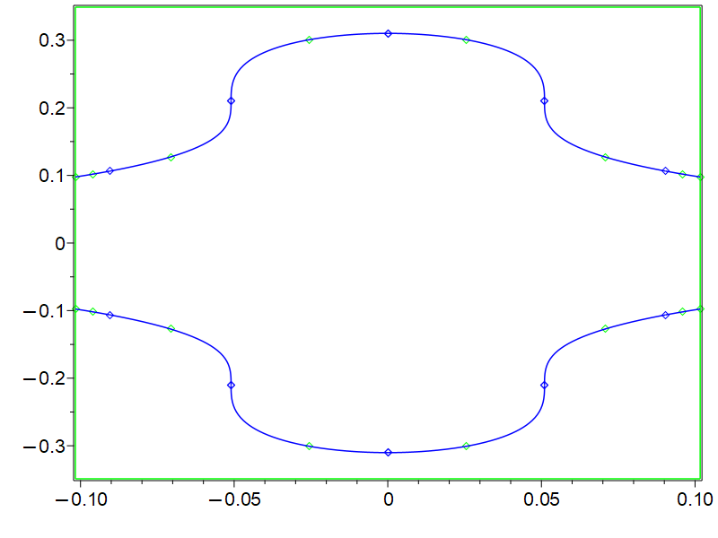

```python
algcurves:-plot_real_curve( eval(steadyR, F=Finflection), sigma, R );
```

```
kilobytes used=289381, alloc=27119, time=23.98
```

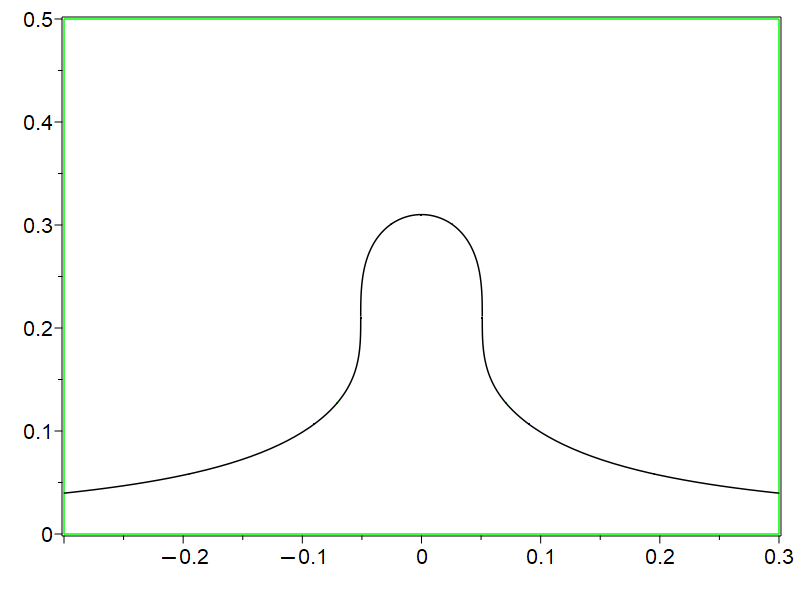

```python
inflectionplot := algcurves:-plot_real_curve( eval(steadyR, F=Finflection), sigma, R, view=[-0.3..0.3, 0..0.5], colorOfCurve=black, symbol=point );
```

To decide the stability, the trace must be negative and the determinant positive.

```python
isolate( factor( eval(tr, F=Finflection) ) < 0, R^2 );
```

$$\frac{3 \mathit{Rinflection}^{2}}{4}<R^{2}$$

```python
factor(eval(eval(dt,sigma^2=SigmaSquared), F=Finflection));
```

$$\frac{36 \left(2 R^{2}+\mathit{Rinflection}^{2}\right) \left(R +\mathit{Rinflection} \right)^{2} \left(\mathit{Rinflection} -R \right)^{2}}{R^{2}}$$

We see that on this curve, the determinant is *always* nonnegative, and is zero only exactly at the inflection point. So, it's neutrally stable there. But when $R^2 < 3 R_i^2/4$, the curve becomes unstable.

```python
dtinflection := algcurves:-plot_real_curve( eval(dt,F=Finflection),
  sigma, R, view=[-0.3..0.3,0..0.5], colorOfCurve="Executive Red",
  symbol=point):
bdyinflection := plot( sqrt(3/4)*Rinflection, sigma=-0.3..0.3,
  color="Executive Blue", view=[-0.3..0.3, 0..0.5] ):
```

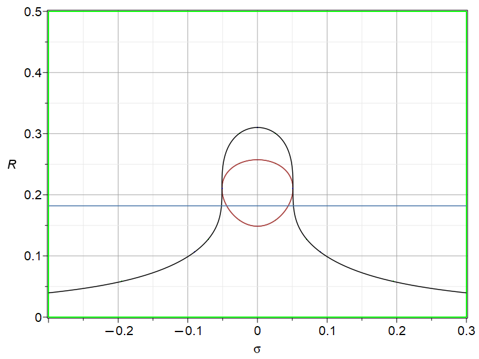

```python
plots[display](dtinflection,inflectionplot, bdyinflection, gridlines, labels=[sigma,R]);
```

Another interesting graph can be found by considering when there are multiple roots when $\sigma=0$.

```python
vert := eval( numer(steadyR), sigma=0 );
```

$$-81 F^{6}+20736 R^{2} F^{4}+147456 R^{4} F^{2}+262144 R^{6}-36864 R^{2} F^{2}-131072 R^{4}+16384 R^{2}$$

```python
facsv := factors( discrim( vert, R) );
lprint( facsv );
```

```
[27411057188552645111135073067585251154329600, [[F^6-256/105*F^4+2048/945*F^2-16384/25515, 2], [F, 18]]]
```

```python
relevant := F^6-256/105*F^4+2048/945*F^2-16384/25515; # Ordering dependent.
```

[output not shown]

$$F^{6}-\frac{256}{105} F^{4}+\frac{2048}{945} F^{2}-\frac{16384}{25515}$$

```python
latex( relevant );
```

```
F^{6}-\frac{256}{105} F^{4}+\frac{2048}{945} F^{2}-\frac{16384}{25515}
```

```python
fsolve( relevant, F ); # real roots only
```

```
                          -0.7818072633, 0.7818072633
```

$$- 0.7818072633, 0.7818072633$$

```python
Fcross := 'Fcross';
alias( Fcross = RootOf(relevant,F) ):
```

```
                               Fcross := Fcross
```

```python
evalf(Fcross);
```

$$ 0.7818072633$$

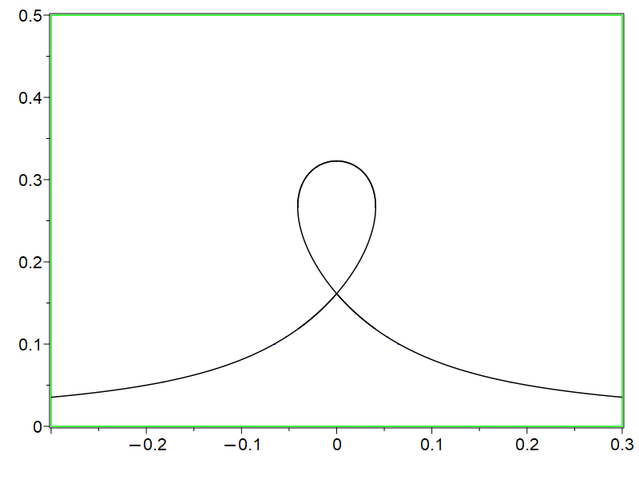

```python
crossplot := algcurves:-plot_real_curve( eval( steadyR, F=Fcross), sigma, R, view=[-0.3..0.3, 0..0.5], colorOfCurve=black, symbol=point );
```

```python
dtcross := algcurves:-plot_real_curve( eval(dt, F=Fcross), sigma, R,
            view=[-0.3..0.3,0..0.5], colorOfCurve="Executive Red",
            symbol=point):
trcross := algcurves:-plot_real_curve( eval(expand(R*tr), F=Fcross),
            sigma, R,
            view=[-0.3..0.3,0..0.5], colorOfCurve="Executive Blue",
            symbol=point):
```

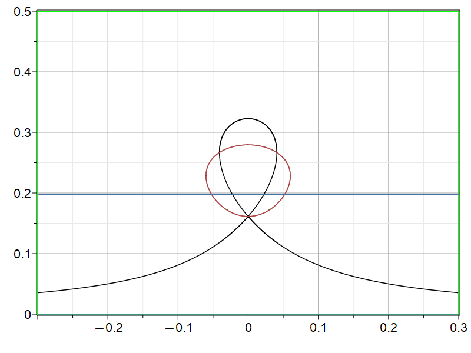

```python
plots[display]( crossplot, dtcross, trcross, gridlines );
```

```python
getR := factors( resultant( vert, diff(vert,R), F )); # multiple roots
lprint( getR );
```

```
[88711656489332649382881390052210717019760230400, [[R+1/2, 6], [R-1/2, 6], [R, 6], [R^6-3/140*R^4+1/560*R^2-1/20160, 2]]]
```

```python
Rcross := 'Rcross';
alias( Rcross = RootOf( R^6-3/140*R^4+1/560*R^2-1/20160, R) );
```

```
                               Rcross := Rcross
```

$$c_{1},c_{2},\mathit{Rinflection},\mathit{Fcross},\mathit{Rcross}$$

```python
facs := factors( eval(vert, F=Fcross));
lprint( facs ); # Linear in R; two positive R, two negative R
```

```
[262144, [[2835/1024*Fcross^5-549/128*Fcross^3+R+2*Fcross, 1], [-2835/1024*Fcross^5+549/128*Fcross^3+R-2*Fcross, 1], [2835/2048*Fcross^5-549/256*Fcross^3+R+Fcross, 2], [-2835/2048*Fcross^5+549/256*Fcross^3+R-Fcross, 2]]]
```

```python
R1 := rhs(isolate(-2835/2048*Fcross^5+549/256*Fcross^3+R-Fcross,R));
R2 := rhs(isolate(-2835/1024*Fcross^5+549/128*Fcross^3+R-2*Fcross,R));
evalf([R1,R2]);
```

[output not shown]

$$[ 0.1613419193, 0.322683839]$$

```
kilobytes used=311363, alloc=27119, time=27.44
```

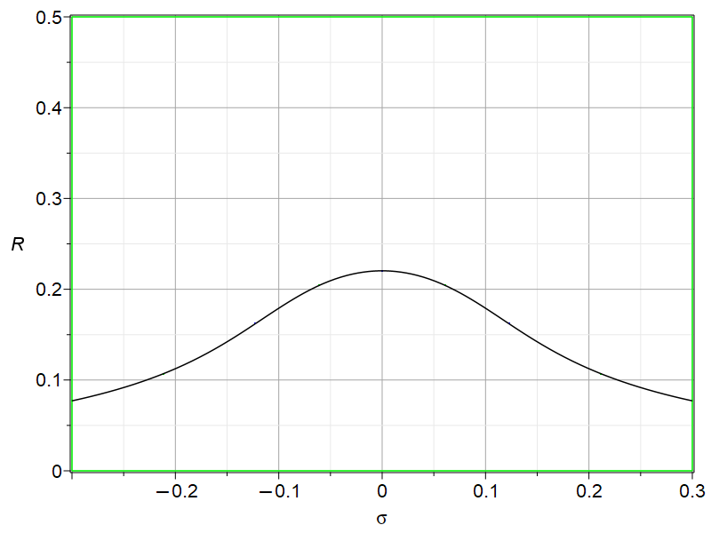

```python
F1plot := algcurves:-plot_real_curve( eval( steadyR, F=1),
  sigma, R, view=[-0.3..0.3, 0..0.5], colorOfCurve=black, symbol=point, gridlines, labels=[sigma,R] );
```

```python
map( factor, eval( [dt,tr], F=1 ) ); # Always stable
```

```
            [9/256 + 9/2 R  + 108 R  + 81/4 sigma , - 3/8 - 24 R ]
```

$$\left[\frac{9}{256}+\frac{9}{2} R^{2}+108 R^{4}+\frac{81}{4} \sigma^{2}, -\frac{3}{8}-24 R^{2}\right]$$

```python
factor(eval(tr, F=1));
```

$$-\frac{3}{8}-24 R^{2}$$

```python
collect( dt, R, factor );
```

$$108 R^{4}+\left(\frac{81 F^{2}}{2}-36\right) R^{2}+\frac{729 F^{4}}{256}-\frac{81 F^{2}}{16}+\frac{9}{4}+\frac{81 \sigma^{2}}{4}$$

```python
evalf( simplify( eval([dt,tr], [F=Fcross, R=R2]) ) ); # stable
```

```
               [0.219550224 + 20.25000000 sigma , -1.561872892]
```

$$[ 0.219550224+ 20.25000000 \sigma^{2}, - 1.561872892]$$

```python
evalf( simplify( eval([dt,tr], [F=Fcross, R=R1]) ) ); # unstable
```

```
                      [20.25000000 sigma , 0.3123745785]
```

$$[ 20.25000000 \sigma^{2}, 0.3123745785]$$

```python
plot34 := algcurves:-plot_real_curve( eval(steadyR, F=3/4),
sigma, R , view=[-0.3..0.3, 0..0.5], colorOfCurve=black, symbol=point):
```

```python
dt34plot := algcurves:-plot_real_curve( eval(dt, F=3/4), sigma, R,
  view=[-0.3..0.3,0..0.5], colorOfCurve="Executive Red", symbol=point):
```

```python
eval(expand(R*tr), F=3/4);
```

$$\frac{141}{128} R -24 R^{3}$$

```python
tr34plot := algcurves:-plot_real_curve( eval(expand(R*tr), F=3/4), sigma, R,
view=[-0.3..0.3, 0..0.5], colorOfCurve="Executive Blue", symbol=point):
```

```
kilobytes used=325804, alloc=27119, time=29.78
```

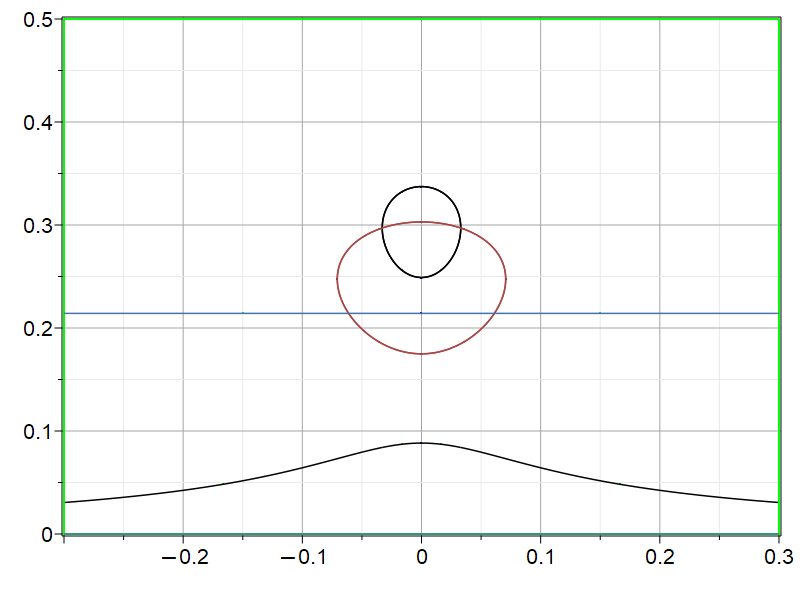

```python
plots[display](plot34, dt34plot, tr34plot, gridlines );
```

```python
nstart := 8;
ncurves := nstart+4 ;
refin := 2; #evalf( (1+sqrt(5))/2 );
flist := [seq( (1-refin^(-k))*Fcross, k=1..nstart-1), Fcross,
          Finflection, 1.01*Finflection,1.02*Finflection, 0.928]; # slices of F
steadyplots := Array(1..ncurves);
dtplots := Array(1..ncurves);
trplots := Array(1..ncurves);
slices := Array(1..ncurves);
for k to ncurves do
  steadyplots[k] := algcurves:-plot_real_curve( eval(steadyR, F=flist[k]),
sigma, R , view=[-0.3..0.3, 0..0.5], colorOfCurve=black, symbol=point);
  dtplots[k] := algcurves:-plot_real_curve( eval(dt, F=flist[k]), sigma, R,
  view=[-0.3..0.3,0..0.5], colorOfCurve="Executive Red", symbol=point);
  trplots[k] := algcurves:-plot_real_curve( eval(expand(R*tr), F=flist[k]), sigma, R,
view=[-0.3..0.3, 0..0.5], colorOfCurve="Executive Blue", symbol=point);
  slices[k] := plots[display]( steadyplots[k], dtplots[k], trplots[k]);
end do:
```

```
kilobytes used=450747, alloc=27119, time=45.27
```

```python
evalf[3]( flist );
```

$$[ 0.391, 0.586, 0.684, 0.734, 0.758, 0.769, 0.776, 0.782, 0.806, 0.815, 0.822, 0.928]$$

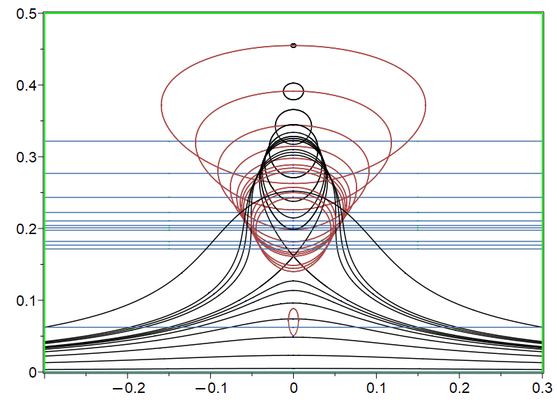

```python
plots[display]( seq( slices[k], k=1..ncurves));
```

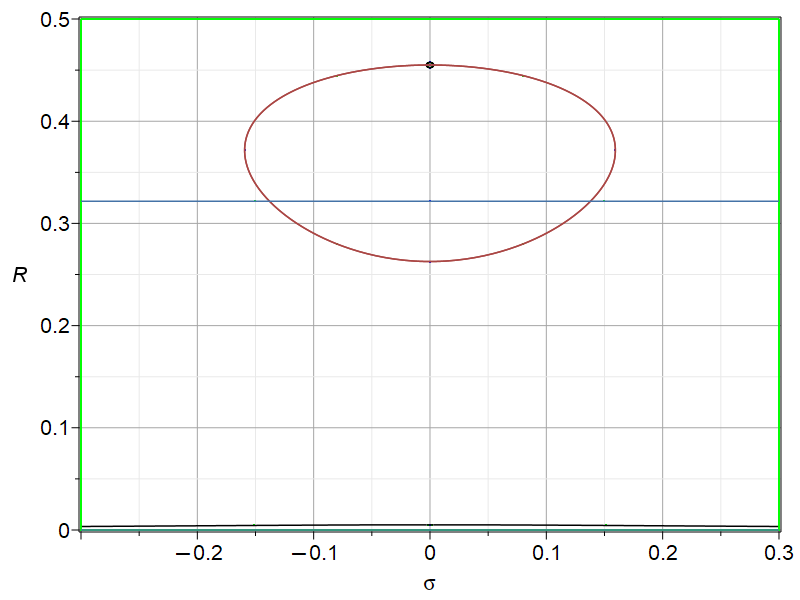

```python
plots[display]( slices[1], gridlines, labels=[sigma,R]);
```

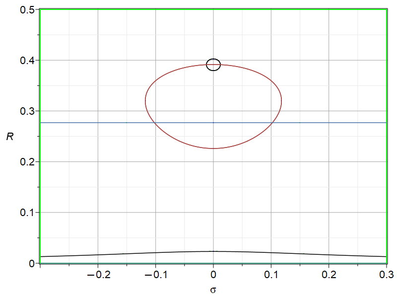

```python
plots[display]( slices[2], gridlines, labels=[sigma,R]);
```

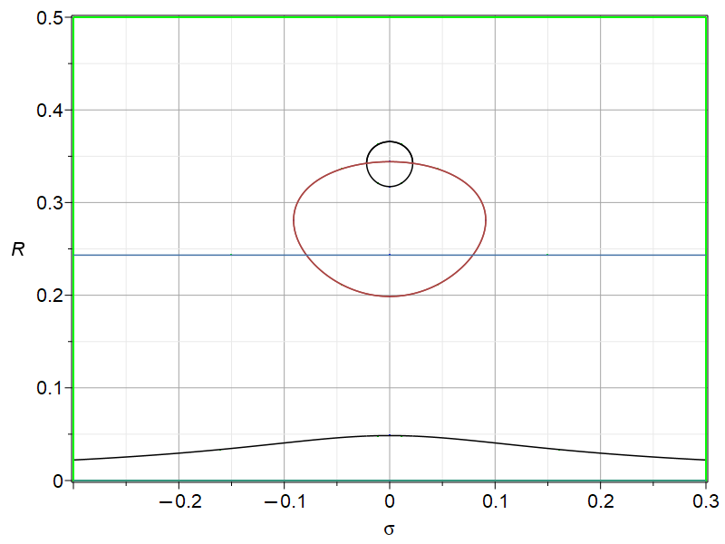

```python
plots[display]( slices[3], gridlines, labels=[sigma,R]);
```

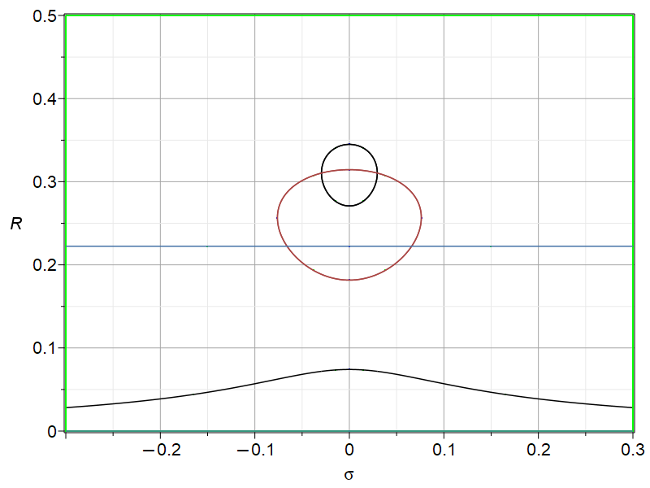

```python
plots[display]( slices[4], gridlines, labels=[sigma,R]);
```

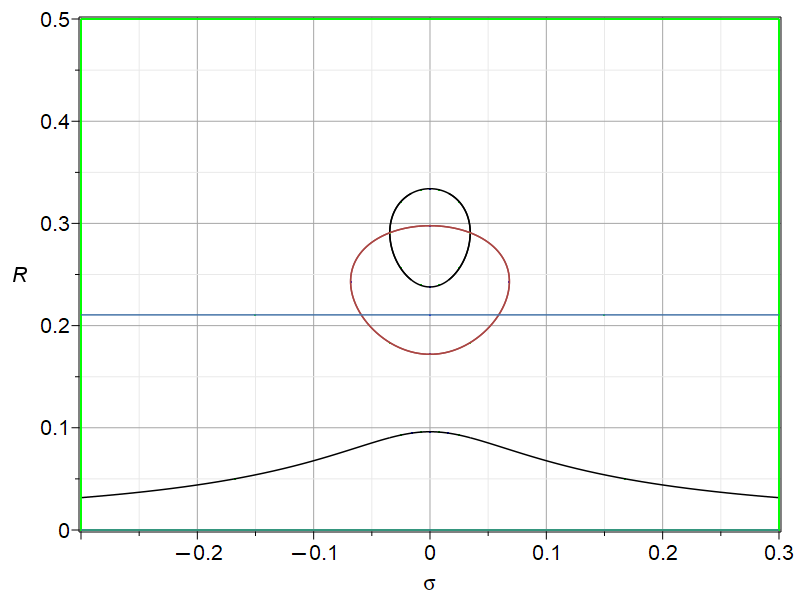

```python
plots[display]( slices[5], gridlines, labels=[sigma,R]);
```

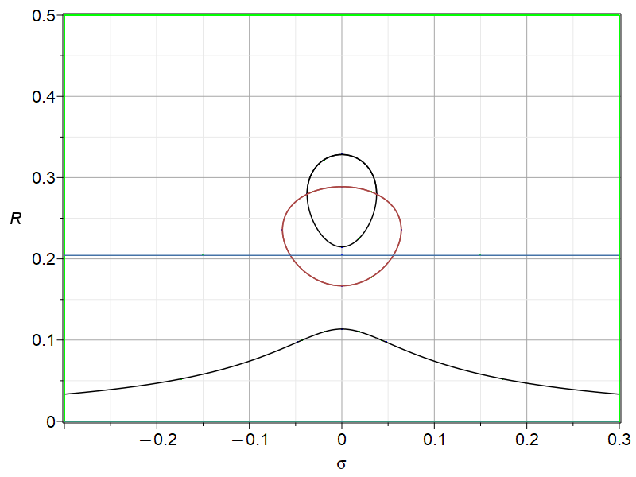

```python
plots[display]( slices[6], gridlines, labels=[sigma,R]);
```

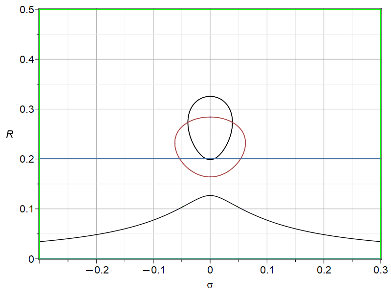

```python
plots[display]( slices[7], gridlines, labels=[sigma,R]);
```

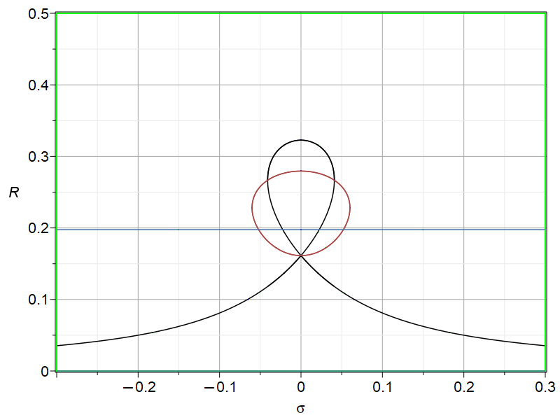

```python
plots[display]( slices[8], gridlines, labels=[sigma,R]);
```

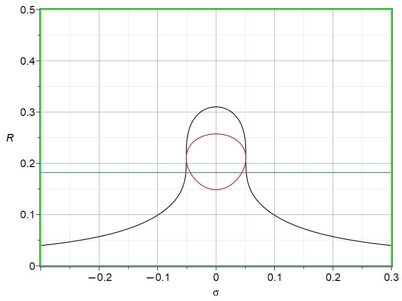

```python
plots[display]( slices[9], gridlines, labels=[sigma,R]);
```

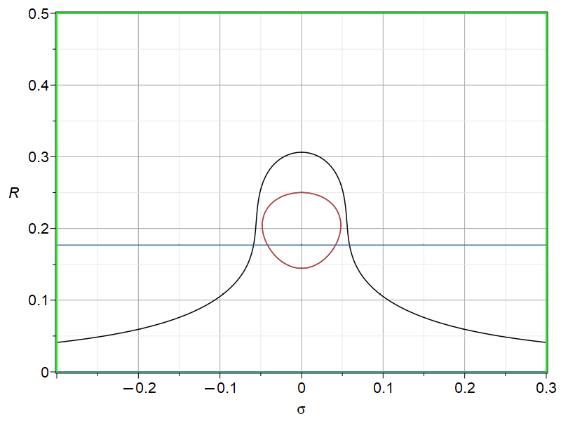

```python
plots[display]( slices[10], gridlines, labels=[sigma,R]);
```

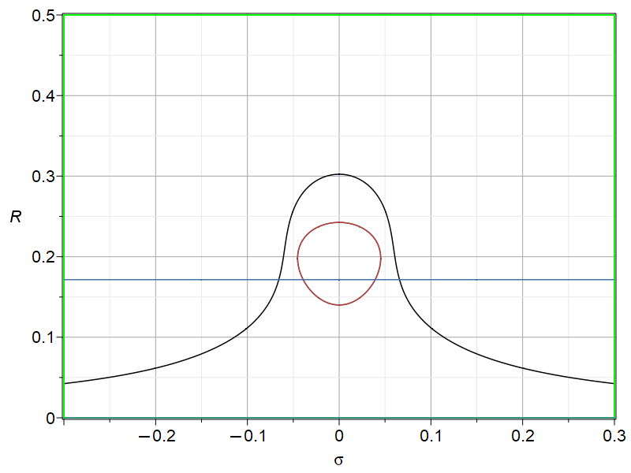

```python
plots[display]( slices[11], gridlines, labels=[sigma,R]);
```

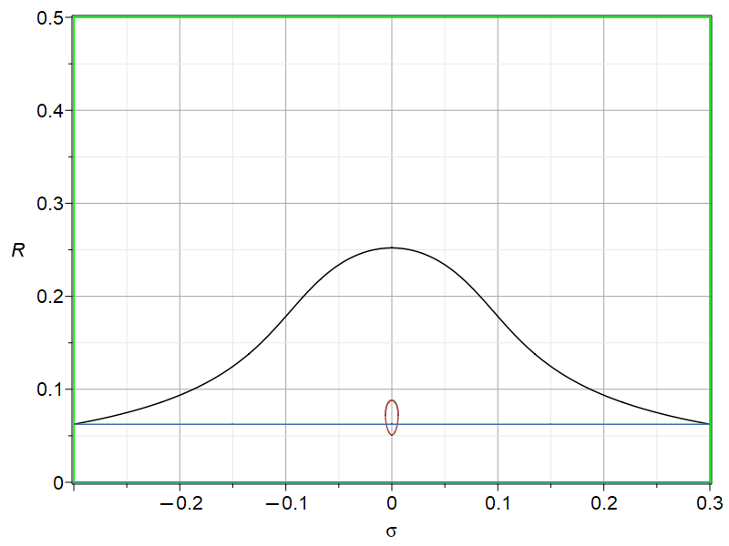

```python
plots[display]( slices[12], gridlines, labels=[sigma,R]);
```

The following construction explains how we found the value of F which made the whole response visible in the window stable. The limiting factor is the trace constraint, so we solve the trace and steady equations together when $\sigma=0.3$ (the edge of the window). We use Groebner bases and the multiplication matrix trick to do so.

```python
allstable := eval([expand(R*tr),steadyR],sigma=3/10)
```

$$\left[-\frac{27}{8} F^{2} R -24 R^{3}+3 R, -81 F^{6}+20736 R^{2} F^{4}+147456 R^{4} F^{2}+262144 R^{6}-36864 R^{2} F^{2}-131072 R^{4}+\frac{741376}{25} R^{2}\right]$$

```python
gb := Groebner:-Basis( allstable, tdeg(R,F));
```

$$[9 F^{2} R +64 R^{3}-8 R, -2025 F^{6}+129600 R^{2} F^{4}-230400 R^{2} F^{2}+434176 R^{2}, 10125 F^{6} R -24300 F^{4} R +44928 F^{2} R -27136 R, 91125 F^{8}-56700 F^{6}-110592 R^{2} F^{2}-3473408 R^{2}]$$

```python
ns,rv := Groebner:-NormalSet( gb, tdeg(R,F) );
```

```
[1, F, R, F^2, R*F, R^2, F^3, F^2*R, R^2*F, F^4, R*F^3, R^2*F^2, F^5, F^4*R, R^2*F^3, F^6, R*F^5, F^7], table([(1)=1,(F^2)=4,(R^2*F)=9,(F^6)=16,(F^7)=18,(F^5)=13,(R^2)=6,(F)=2,(R*F^3)=11,(R^2*F^2)=12,(F^4)=10,(R)=3,(F^3)=7,(R*F^5)=17,(R*F)=5,(F^4*R)=14,(R^2*F^3)=15,(F^2*R)=8])
```

```python
MF := Groebner:-MultiplicationMatrix(F, ns, rv, gb, tdeg(R,F));
```

$$\left[\begin{array}{ccccccccccc} 0 & 1 & 0 & 0 & 0 & 0 & 0 & 0 & 0 & 0 & \mathit{...} \\ 0 & 0 & 0 & 1 & 0 & 0 & 0 & 0 & 0 & 0 & \mathit{...} \\ 0 & 0 & 0 & 0 & 1 & 0 & 0 & 0 & 0 & 0 & \mathit{...} \\ 0 & 0 & 0 & 0 & 0 & 0 & 1 & 0 & 0 & 0 & \mathit{...} \\ 0 & 0 & 0 & 0 & 0 & 0 & 0 & 1 & 0 & 0 & \mathit{...} \\ 0 & 0 & 0 & 0 & 0 & 0 & 0 & 0 & 1 & 0 & \mathit{...} \\ 0 & 0 & 0 & 0 & 0 & 0 & 0 & 0 & 0 & 1 & \mathit{...} \\ 0 & 0 & 0 & 0 & 0 & 0 & 0 & 0 & 0 & 0 & \mathit{...} \\ 0 & 0 & 0 & 0 & 0 & 0 & 0 & 0 & 0 & 0 & \mathit{...} \\ 0 & 0 & 0 & 0 & 0 & 0 & 0 & 0 & 0 & 0 & \mathit{...} \\ \mathit{:} & \mathit{:} & \mathit{:} & \mathit{:} & \mathit{:} & \mathit{:} & \mathit{:} & \mathit{:} & \mathit{:} & \mathit{:} & \text{``18 x 18 Matrix''} \end{array}\right]$$

```python
MR := Groebner:-MultiplicationMatrix(R, ns, rv, gb, tdeg(R,F));
```

$$\left[\begin{array}{ccccccccccc} 0 & 0 & 1 & 0 & 0 & 0 & 0 & 0 & 0 & 0 & \mathit{...} \\ 0 & 0 & 0 & 0 & 1 & 0 & 0 & 0 & 0 & 0 & \mathit{...} \\ 0 & 0 & 0 & 0 & 0 & 1 & 0 & 0 & 0 & 0 & \mathit{...} \\ 0 & 0 & 0 & 0 & 0 & 0 & 0 & 1 & 0 & 0 & \mathit{...} \\ 0 & 0 & 0 & 0 & 0 & 0 & 0 & 0 & 1 & 0 & \mathit{...} \\ 0 & 0 & \frac{1}{8} & 0 & 0 & 0 & 0 & -\frac{9}{64} & 0 & 0 & \mathit{...} \\ 0 & 0 & 0 & 0 & 0 & 0 & 0 & 0 & 0 & 0 & \mathit{...} \\ 0 & 0 & 0 & 0 & 0 & 0 & 0 & 0 & 0 & 0 & \mathit{...} \\ 0 & 0 & 0 & 0 & \frac{1}{8} & 0 & 0 & 0 & 0 & 0 & \mathit{...} \\ 0 & 0 & 0 & 0 & 0 & 0 & 0 & 0 & 0 & 0 & \mathit{...} \\ \mathit{:} & \mathit{:} & \mathit{:} & \mathit{:} & \mathit{:} & \mathit{:} & \mathit{:} & \mathit{:} & \mathit{:} & \mathit{:} & \text{``18 x 18 Matrix''} \end{array}\right]$$

```python
alph := rand()*Float(1,-12);
```

$$ 0.9608097424$$

```python
Mrand := alph*MF + (1-alph)*MR:
E,V := LinearAlgebra:-Eigenvectors(Mrand,output=['values','vectors']):
```

```python
pairs := [seq( [V[2,k]/V[1,k], V[3,k]/V[1,k]], k=1..18)]:
select( t->abs(Im(t[1]))<1.0e-5 and abs(Im(t[2]))<1.0e-5, pairs );
```

$$[[ 0.0+ 0.0 \mathrm{I} , 0.0+ 0.0 \mathrm{I}], [-{ 1.87732434883778061\times 10^{-291}}- 0.0 \mathrm{I} , 0.0- 0.0 \mathrm{I}], [ 0.927996278481702741+ 0.0 \mathrm{I} , 0.0624257263820959044+ 0.0 \mathrm{I}], [ 0.927996278481703074+ 0.0 \mathrm{I} , - 0.0624257263822363545+ 0.0 \mathrm{I}], [- 0.927996278481695303+ 0.0 \mathrm{I} , - 0.0624257263820099592+ 0.0 \mathrm{I}], [- 0.927996278481694747+ 0.0 \mathrm{I} , 0.0624257263819347624+ 0.0 \mathrm{I}], [ 0.000280739708817708748+ 0.0 \mathrm{I} , -{ 1.10208455500287483\times 10^{-22}}- 0.0 \mathrm{I}], [- 0.000280818179175170151- 0.0 \mathrm{I} , -{ 1.11530352722275924\times 10^{-22}}- 0.0 \mathrm{I}]]$$

Looks like $F=0.928$ will make everything visible in the window stable.

```python
ssample := sqrt( evalf( eval(SigmaSquared, [F=Finflection,R=Rinflection]) ) );
```

$$ 0.05100116273$$

```python
de1 := diff(g(t),t) = expand(eval( diff(R(tau),tau)/e,
  [R(tau)=g(t), theta(tau)=psi(t)] ));
```

$$\frac{d}{d t}g \left(t \right) = -\frac{1215 \varepsilon \sin \left(\psi \left(t \right)\right) F^{5}}{32768}+\frac{2727 g \left(t \right)^{2} \varepsilon \sin \left(\psi \left(t \right)\right) F^{3}}{1024}+\frac{729 \varepsilon \,F^{3} \cos \left(\psi \left(t \right)\right) \sigma}{2048}+\frac{189 \varepsilon \,F^{3} \sin \left(\psi \left(t \right)\right)}{2048}-\frac{243 g \left(t \right) \varepsilon \sigma \,F^{2}}{64}+9 g \left(t \right)^{3} \varepsilon \sigma -\frac{9 g \left(t \right) \varepsilon \sigma}{4}+\frac{27 \cos \left(\psi \left(t \right)\right) F^{3}}{256}-\frac{27 g \left(t \right) F^{2}}{16}-6 g \left(t \right)^{3}+\frac{3 g \left(t \right)}{2}$$

```python
de2 := diff(psi(t),t) = expand(eval( diff(theta(tau),tau)/e,
  [R(tau)=g(t), theta(tau)=psi(t)] ));
```

$$\frac{d}{d t}\psi \left(t \right) = -\frac{1215 F^{5} \cos \left(\psi \left(t \right)\right) \varepsilon}{32768 g \left(t \right)}+\frac{2565 F^{3} \cos \left(\psi \left(t \right)\right) g \left(t \right) \varepsilon}{1024}-\frac{6075 F^{4} \varepsilon}{8192}-\frac{729 F^{3} \sin \left(\psi \left(t \right)\right) \sigma \varepsilon}{2048 g \left(t \right)}-\frac{3159 F^{2} g \left(t \right)^{2} \varepsilon}{320}+3 g \left(t \right)^{4} \varepsilon +\frac{189 \cos \left(\psi \left(t \right)\right) \varepsilon \,F^{3}}{2048 g \left(t \right)}-\frac{27 F^{3} \sin \left(\psi \left(t \right)\right)}{256 g \left(t \right)}+\frac{27 \varepsilon \,F^{2}}{32}+\frac{27 \sigma^{2} \varepsilon}{4}-\frac{9 \sigma}{2}-\frac{3 \varepsilon}{8}$$

```python
deqs := eval({de1,de2},
  [e=0.01, F=evalf(Finflection), R=evalf(Rinflection), sigma=0.05])
   union {g(0)=0.4, psi(0)=0.0};
```

$$\left\{\frac{d}{d t}g \left(t \right) = 0.0003594094267 \sin \left(\psi \left(t \right)\right)+ 0.01406302353 g \left(t \right)^{2} \sin \left(\psi \left(t \right)\right)+ 0.05578912825 \cos \left(\psi \left(t \right)\right)+ 0.3951494330 g \left(t \right)- 5.9955 g \left(t \right)^{3}, \frac{d}{d t}\psi \left(t \right) = \frac{ 0.0003594094267 \cos \left(\psi \left(t \right)\right)}{g \left(t \right)}+ 0.01322759639 \cos \left(\psi \left(t \right)\right) g \left(t \right)- 0.2262341199-\frac{ 0.05578912825 \sin \left(\psi \left(t \right)\right)}{g \left(t \right)}- 0.06449538838 g \left(t \right)^{2}+ 0.03 g \left(t \right)^{4}, g \left(0\right) = 0.4, \psi \left(0\right) = 0.0\right\}$$

```python
numsol := dsolve(deqs , {g(t),psi(t)}, numeric ):
```

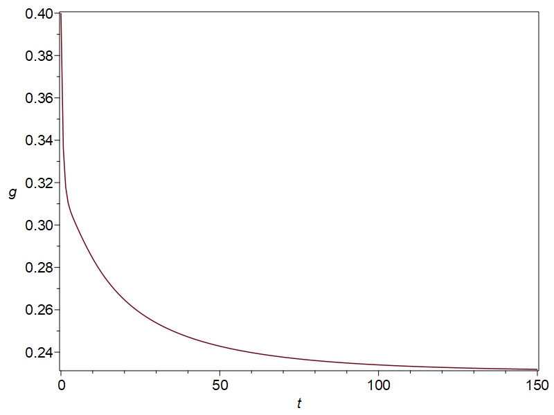

```python
plots[odeplot]( numsol, [t, (g)(t)], t=0..150);
```

```python
clearer := student[completesquare]( eval(dt,[F=sqrt(F2),R=sqrt(RR2)]), F2);
```

$$\frac{729 \left(\mathit{F2} +\frac{64 \mathit{RR2}}{9}-\frac{8}{9}\right)^{2}}{256}-36 \mathit{RR2}^{2}+\frac{81 \sigma^{2}}{4}$$